# Notebook 15 – Solutions

## Getting Started

Before running this notebook, select “Session > Restart R and Clear Output” in the menu above to start a new R session. This will clear any old data sets and give us a blank slate to start with.

## What We Eat in America

Today we will continue to look at the *What We Eat in America* dataset. We can read the tables in with the following:

```r
food <- read_csv("../data/wweia_food.csv.bz2")
demo <- read_csv("../data/wweia_demo.csv.bz2")
meta <- read_csv("../data/wweia_meta.csv.bz2")
```

We will do some more practice joining and reorganizing the food data, this type using more of the `meta` table, which we have not yet looked at.

## Food Groups: Calories, Sugar, and Fat

To start, create a dataset that shows the average number of calories that each participants consumes based on the `food_group` of the food item. The food group can be found in the `meta` table. Note that the easiest way to do this is to take the sume of the variable `kcal` and divide by `nrow(demo)` (the number of people).

```r
# Question 01
food |>
  left_join(meta, by = "food_code") |>
  group_by(food_group) |>
  summarize(kcal = sum(kcal) / nrow(demo)) |>
  arrange(desc(kcal))
```

```
## # A tibble: 13 × 2
##    food_group              kcal
##    <chr>                  <dbl>
##  1 Mixed Dishes          472.
##  2 Snacks and Sweets     284.
##  3 Protein Foods         248.
##  4 Beverages             202.
##  5 Grains                185.
##  6 Milk and Dairy        106.
##  7 Vegetables             91.0
##  8 Fats and Oils          48.5
##  9 Fruit                  45.6
## 10 Condiments and Sauces  20.2
## 11 Sugars                 18.7
## 12 Baby Foods             16.1
## 13 Other                   4.93
```

Now, create a scatterplot with one dot for each food group. The x-coordinate should correspond to the average number of calories participants consume from this group and the y-coordinate should be the average grams of sugar each participant consumes from the food group. Add a text repel layer with the food group names.

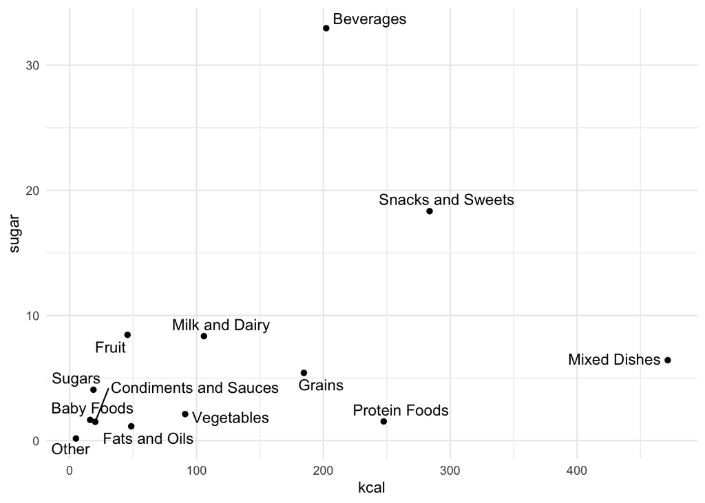

```r
# Question 02
food |>
  left_join(meta, by = "food_code") |>
  group_by(food_group) |>
  summarize(kcal = sum(kcal) / nrow(demo), sugar = sum(sugar) / nrow(demo)) |>
  ggplot(aes(kcal, sugar)) +
    geom_point() +
    geom_text_repel(aes(label = food_group))
```

Below, repeat the previous question but now include a linear regression line. Do this use the `lm` and `augement` functions (e.g., not with `geom_smooth`). Take note of any outliers.

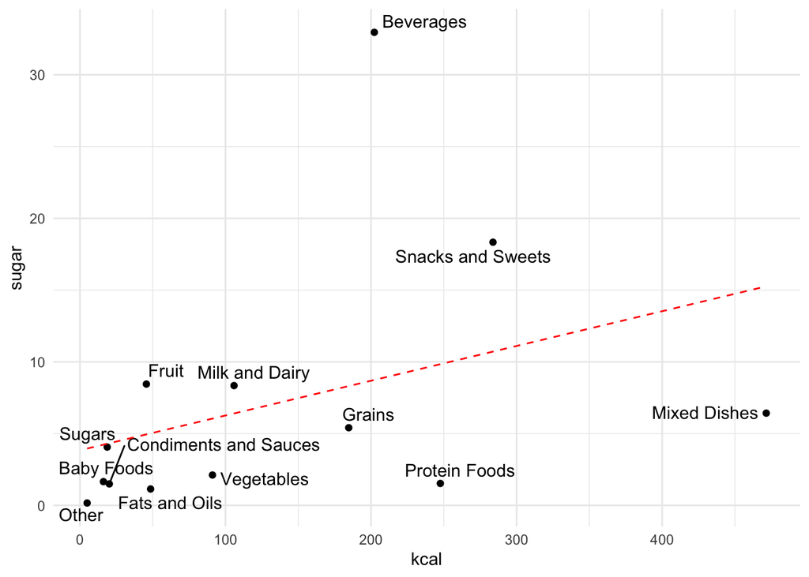

```r
# Question 03
temp <- food |>
  left_join(meta, by = "food_code") |>
  group_by(food_group) |>
  summarize(kcal = sum(kcal) / nrow(demo), sugar = sum(sugar) / nrow(demo))

model <- lm(sugar ~ kcal, data = temp)

augment(model, newdata = temp) |>
  ggplot(aes(kcal, sugar)) +
    geom_point() +
    geom_text_repel(aes(label = food_group)) +
    geom_line(aes(y = .fitted), color = "red", linetype = "dashed")
```

In the next block of code, repeat the previous question but this time use the average amount of fat in place of the average amount of sugar. Hint: this should be an easy change.

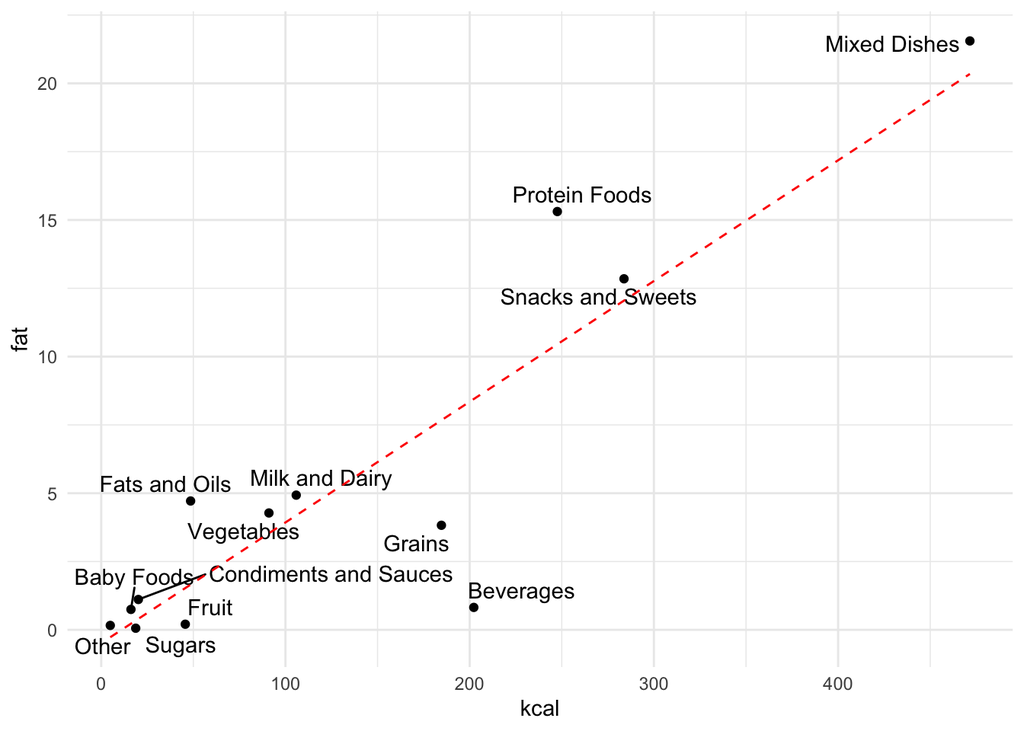

```r
# Question 04
temp <- food |>
  left_join(meta, by = "food_code") |>
  group_by(food_group) |>
  summarize(kcal = sum(kcal) / nrow(demo), fat = sum(fat) / nrow(demo))

model <- lm(fat ~ kcal, data = temp)

augment(model, newdata = temp) |>
  ggplot(aes(kcal, fat)) +
    geom_point() +
    geom_text_repel(aes(label = food_group)) +
    geom_line(aes(y = .fitted), color = "red", linetype = "dashed")
```

In the following plot, create a similar plot as you did in the previous question, but instead of a point for each food group, use a line segment going from the average values for Female participants towards the averages for Male participants. You do not need a regression line here. You may need to tweak the colors to be able to see all of the food groups.

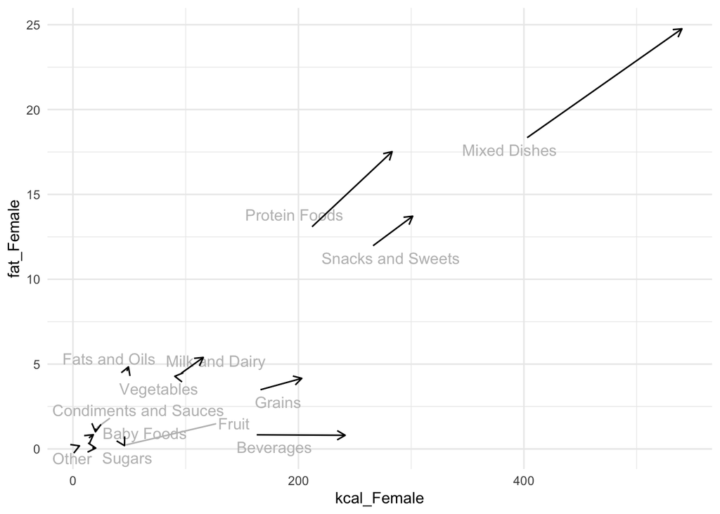

```r
# Question 05
# In the solution I am assuming that the number of Male and Female participants
# are the same, which is close but not 100% correct. You could do a better job
# by creating two tables and then joining them.
food |>
  left_join(meta, by = "food_code") |>
  left_join(demo, by = "id") |>
  group_by(gender, food_group) |>
  summarize(kcal = sum(kcal) / nrow(demo) * 2, fat = sum(fat) / nrow(demo) * 2) |>
  pivot_wider(names_from = c(gender), values_from = c(kcal, fat)) |>
  ggplot(aes(kcal_Female, fat_Female)) +
    geom_text_repel(aes(label = food_group), color = "grey") +
    geom_segment(
      aes(xend = kcal_Male, yend = fat_Male),
      arrow = arrow(length = unit(0.02, "npc"))
    )
```

### A More Complex Plot

For the most part, our analyses have been able to get by using a single set of pipes. Sometimes, more complex analyses require use to modify a dataset in multiple incompatible ways, storing these as individual tables, and then joining them on a common key. We’ll practice that here.

Our goal is to see how the relationship between the average amount of calories consumed for breakfast within an age group is related to the average amount of food that was prepared from ingredients bought at a store.

First, create and save a dataset that breaks the ages in the dataset into buckets of 5 years each and computes the proportion of calories within each bucket that were consumed at either Breakfast or Desayano (Spanish for Breakfast). You’ll probably need a pivot for this.

```r
# Question 07
tab1 <- food |>
  left_join(demo, by = "id")  |>
  mutate(age = cut(age, breaks = seq(0, 80, by = 5), include.lowest = TRUE)) |>
  group_by(age, meal_name) |>
  summarize(kcal = sum(kcal)) |>
  mutate(total_kcal = sum(kcal)) |>
  pivot_wider(names_from = c(meal_name), values_from = c(kcal), values_fill = 0) |>
  mutate(prop_breakfast = 100 * (Breakfast + Desayano) / total_kcal) |>
  select(age, prop_breakfast)
tab1
```

```
## # A tibble: 16 × 2
## # Groups:   age [16]
##    age     prop_breakfast
##    <fct>            <dbl>
##  1 [0,5]             17.5
##  2 (5,10]            17.6
##  3 (10,15]           15.4
##  4 (15,20]           15.4
##  5 (20,25]           13.6
##  6 (25,30]           14.4
##  7 (30,35]           16.7
##  8 (35,40]           16.0
##  9 (40,45]           14.9
## 10 (45,50]           15.8
## 11 (50,55]           17.1
## 12 (55,60]           16.8
## 13 (60,65]           18.8
## 14 (65,70]           19.8
## 15 (70,75]           20.2
## 16 (75,80]           20.5
```

In the code block below, create a similar table, but this time we want to compute the proportion of calories consumed from items bought at a Store. The names for the `food_source` variable are fairly messy; so as a first step, use the following mutate function to take just the first 5 characters of the food source name:

`mutate(food_source = stri_sub(food_source, 1, 5)) |>`

Then, the rest of the code should be similar to the answer above.

```r
# Question 08
tab2 <- food |>
  mutate(food_source = stri_sub(food_source, 1, 5)) |>
  left_join(demo, by = "id")  |>
  mutate(age = cut(age, breaks = seq(0, 80, by = 5), include.lowest = TRUE)) |>
  group_by(age, food_source) |>
  summarize(kcal = sum(kcal)) |>
  mutate(total_kcal = sum(kcal)) |>
  pivot_wider(names_from = c(food_source), values_from = c(kcal), values_fill = 0) |>
  mutate(prop_store = 100 * (Store) / total_kcal) |>
  select(age, prop_store)
tab2
```

```
## # A tibble: 16 × 2
## # Groups:   age [16]
##    age     prop_store
##    <fct>        <dbl>
##  1 [0,5]         76.1
##  2 (5,10]        61.4
##  3 (10,15]       60.6
##  4 (15,20]       53.6
##  5 (20,25]       58.5
##  6 (25,30]       57.6
##  7 (30,35]       60.5
##  8 (35,40]       63.2
##  9 (40,45]       63.4
## 10 (45,50]       63.6
## 11 (50,55]       67.0
## 12 (55,60]       69.1
## 13 (60,65]       71.8
## 14 (65,70]       71.2
## 15 (70,75]       75.5
## 16 (75,80]       72.5
```

Finally, put the two tables you saved from questions 7 and 8 together and plot the two proportions on the x- and y-axes. Include labels showing the age buckets. If you have time, try to add a linear regression line and some labels, title, etc. to the plot.

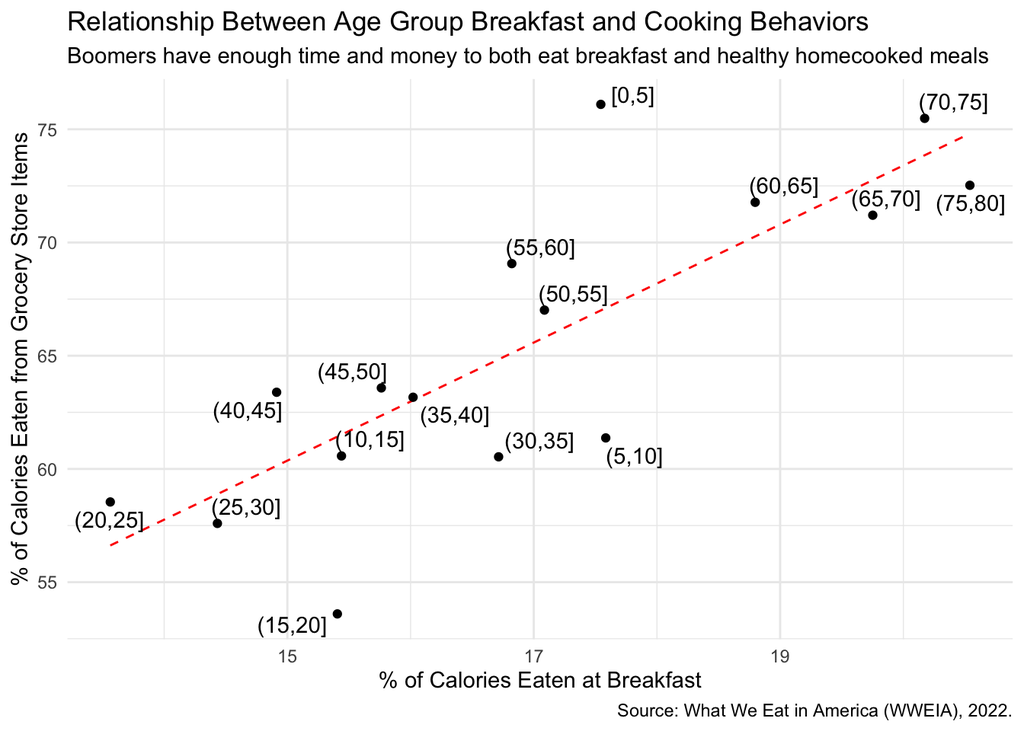

```r
# Question 09
temp <- tab1 |>
  left_join(tab2, by = "age")
model <- lm(prop_store ~ prop_breakfast, data = temp)

augment(model, newdata = temp) |>
  ggplot(aes(prop_breakfast, prop_store)) +
    geom_line(aes(y = .fitted), color = "red", linetype = "dashed") +
    geom_point() +
    geom_text_repel(aes(label = age)) +
    labs(x = "% of Calories Eaten at Breakfast",
         y = "% of Calories Eaten from Grocery Store Items",
         title = "Relationship Between Age Group Breakfast and Cooking Behaviors",
         subtitle = "Boomers have enough time and money to both eat breakfast and healthy homecooked meals",
         caption = "Source: What We Eat in America (WWEIA), 2022."
         )
```